# Comparing Population Estimates for Trafford

## Mid Year 2022

ONS has published the Mid-Year 2022 population estimates for England and Wales including local authority levels.

Trafford population was 236,301, 715 more than the population in Mid-Year 2021 and 1,249 more than the population reported by the Census 2021.

From the Census 2021 to Mid-Year 2022 the population has grow 0.53%, this is 1% less than GM at 1.53% grow and 0.56% less than England at 1.09%.

From Mid-Year 2021 to Mid-Year 2022 the population has grow 0.3%, this is 1.16% less than GM at 1.47% grow and 0.67% less than England at 0.97%. Trafford has the lowest growth compared to the rest of GM authorities.

The median age in Trafford was 41 years, 0.2 years more than the median age in Mid-Year 2021. Trafford had the third highest median age among GM authorities. GM median age is 37.3 years and England’s median age is 40.5 years.

Comparing the change from Census 2021 to Mid 2022, Females under 5 years had the largest decrease in growth and number of residents with -5.6% and -376 respectively. Males aged 45 to 49 had the largest decrease in growth and number of residents with -3.1% and -250 respectively.

Females aged 75 to 79 had the largest increase in growth and number of residents at 10.5% and 460 respectively. Males aged 75 to 79 had the largest increase in growth at 8.8%, however, the largest increase in number of residents for Males was age band 10 to 14 at 428.

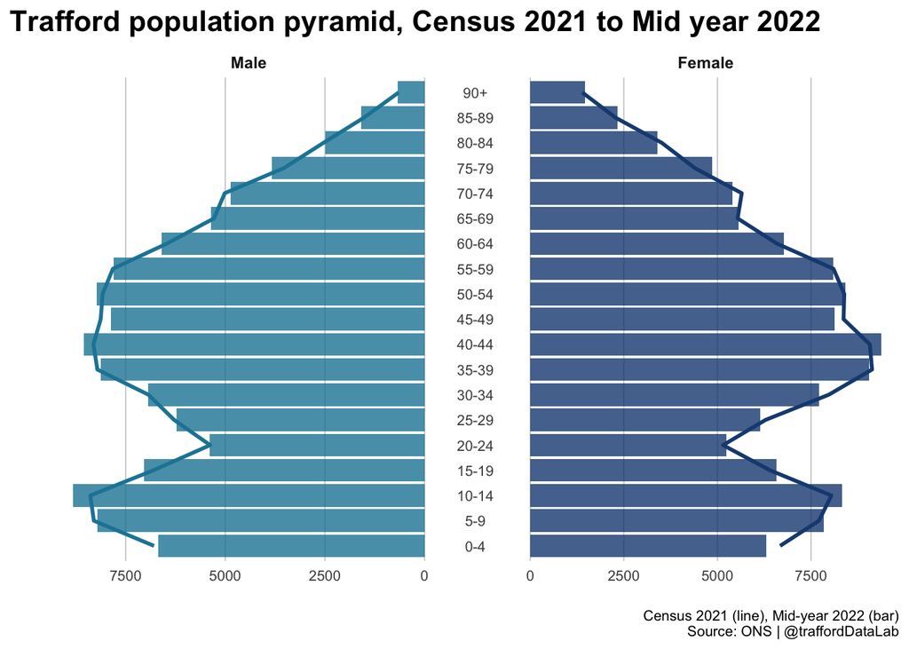

From Mid-Year 2021 to Mid-Year 2022 there was an estimate of 2,274 births and 2,103 deaths, with a surplus of births over deaths of 171. The Internal Migration inflow was 13,629 and the Internal Migration outflow was 14,870, with a net Internal Migration of -1,241. The International Migration inflow was 3,048 and the International Migration outflow was 1,261, with a net international migration of 1,787. Other changes account for -2.

Internal migration outflow is larger than the internal migration inflow for Trafford, England and the rest of the GM authorities except for Salford and Wigan which had a large internal migration inflow. Net International migration is the largest component of population growth for Trafford and all GM authorities, and England.

Births minus deaths or natural change has decline over the years. Net Internal Migration have gone from adding over 1,000 residents in 2013 to deducting residents from 2019, reaching -1,241 in 2022. Net International Migration has notably increased particularly in 2022 after negative numbers in 2019 and 2020.

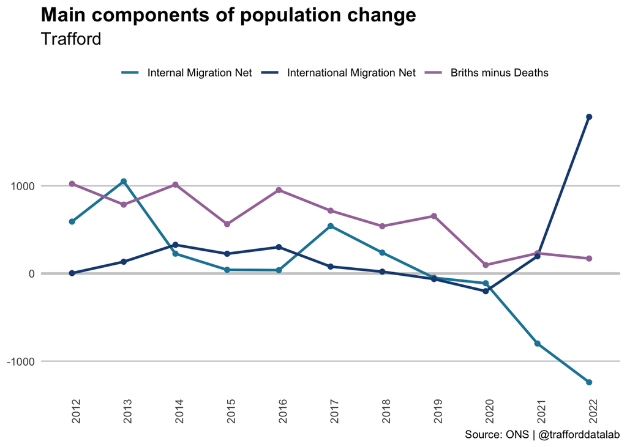